# Copy_of_Train_invoice_object_detection

```python
!pip install numpy==1.17.4
```

```
     |████████████████████████████████| 20.0MB 1.5MB/s
ERROR: datascience 0.10.6 has requirement folium==0.2.1, but you'll have folium 0.8.3 which is incompatible.
ERROR: albumentations 0.1.12 has requirement imgaug<0.2.7,>=0.2.5, but you'll have imgaug 0.2.9 which is incompatible.
  Found existing installation: numpy 1.18.5
    Uninstalling numpy-1.18.5:
      Successfully uninstalled numpy-1.18.5
```

```python
%tensorflow_version 1.x
```

```
TensorFlow 1.x selected.
```

```python
from sklearn.model_selection import train_test_split
from PIL import Image
import tensorflow as tf
import numpy as np
import matplotlib.pyplot as plt

import imutils
import os
```

```python
print('tf version ', tf.__version__)
print('np version ', np.__version__)
```

```
tf version  1.15.2
np version  1.18.5
```

### Environment configuration

We need:

- Tensorflow object detection API: For this we are going to clone the repository
- We need to install some needed packages in the system
- We need compile object detection API

```python
!git clone https://github.com/tensorflow/models.git
!git clone https://github.com/deybvagm/invoice-object-detection.git
!mv invoice-object-detection res
```

```
Cloning into 'models'...
remote: Enumerating objects: 66, done.
remote: Counting objects: 100% (66/66), done.
remote: Compressing objects: 100% (57/57), done.
remote: Total 42162 (delta 30), reused 45 (delta 9), pack-reused 42096
Receiving objects: 100% (42162/42162), 549.35 MiB | 30.52 MiB/s, done.
Resolving deltas: 100% (28651/28651), done.
Cloning into 'invoice-object-detection'...
remote: Enumerating objects: 67, done.
remote: Counting objects: 100% (67/67), done.
remote: Compressing objects: 100% (63/63), done.
remote: Total 67 (delta 18), reused 27 (delta 2), pack-reused 0
Unpacking objects: 100% (67/67), done.
```

```python
!apt-get install protobuf-compiler python-pil python-lxml python-tk
!pip install Cython
```

[output not shown]

[output cut: 13 more lines]

[output not shown]

```python
%cd '/content/models/'
!git checkout c9f03bf6a8ae58b9ead119796a6c3cd9bd04d450
!mv /content/res/resources/*.py '/content/models/research/object_detection/'
```

```
/content/models
Checking out files: 100% (3327/3327), done.
Note: checking out 'c9f03bf6a8ae58b9ead119796a6c3cd9bd04d450'.

You are in 'detached HEAD' state. You can look around, make experimental
changes and commit them, and you can discard any commits you make in this
state without impacting any branches by performing another checkout.

If you want to create a new branch to retain commits you create, you may
do so (now or later) by using -b with the checkout command again. Example:

  git checkout -b <new-branch-name>

HEAD is now at c9f03bf6 Merge pull request #5870 from ofirnachum/master
```

```python
# compile model definition
%cd '/content/models/research/'
!protoc object_detection/protos/*.proto --python_out=.
```

```
/content/models/research
```

```python
# set the environment
os.environ['PYTHONPATH'] += ':/content/models/research/:/content/models/research/slim'
```

```python
!python setup.py build
!python setup.py install
```

[output not shown]

[output cut: 1280 more lines]

[output not shown]

```python
# to test if everything is ok
!python /content/models/research/object_detection/builders/model_builder_test.py
```

[output not shown]

[output cut: 12 more lines]

```
[       OK ] ModelBuilderTest.test_create_ssd_mobilenet_v2_fpnlite_model_from_config
[ RUN      ] ModelBuilderTest.test_create_ssd_mobilenet_v2_keras_model_from_config
[       OK ] ModelBuilderTest.test_create_ssd_mobilenet_v2_keras_model_from_config
[ RUN      ] ModelBuilderTest.test_create_ssd_mobilenet_v2_model_from_config
[       OK ] ModelBuilderTest.test_create_ssd_mobilenet_v2_model_from_config
[ RUN      ] ModelBuilderTest.test_create_ssd_resnet_v1_fpn_model_from_config
[       OK ] ModelBuilderTest.test_create_ssd_resnet_v1_fpn_model_from_config
[ RUN      ] ModelBuilderTest.test_create_ssd_resnet_v1_ppn_model_from_config
[       OK ] ModelBuilderTest.test_create_ssd_resnet_v1_ppn_model_from_config
[ RUN      ] ModelBuilderTest.test_session
[  SKIPPED ] ModelBuilderTest.test_session
----------------------------------------------------------------------
Ran 22 tests in 0.135s

OK (skipped=1)
```

```python
# create a symbolic link to avoid writting complete paths
%cd '/content/'
!ln -s '/content/models/research/object_detection/' object_detection
```

```
/content
```

```python
# Object detection imports
from object_detection.utils.dataset_util import bytes_list_feature
from object_detection.utils.dataset_util import float_list_feature
from object_detection.utils.dataset_util import int64_list_feature
from object_detection.utils.dataset_util import int64_feature
from object_detection.utils.dataset_util import bytes_feature
from object_detection.utils import label_map_util
```

### Helper functions

In order that Tensorflow could understand the data we have we need to create standard Tensorflow Records that basically have the following info:

- The image (encoded)
- Bounding boxes coordinates
- Format: JPG, PNG, etc
- Labels
- Image dimensions (width, height)

```python
class TFAnnotation:
  def __init__(self):
    # initialize the bounding box + label lists
    self.xMins = []
    self.xMaxs = []
    self.yMins = []
    self.yMaxs = []
    self.textLabels = []
    self.classes = []
    self.difficult = []

    # initialize additional variables, including the image
    # itself, spatial dimensions, encoding, and filename
    self.image = None
    self.width = None
    self.height = None
    self.encoding = None
    self.filename = None

  def build(self):
    # encode the attributes using their respective TensorFlow
    # encoding function
    w = int64_feature(self.width)
    h = int64_feature(self.height)
    filename = bytes_feature(self.filename.encode("utf8"))
    encoding = bytes_feature(self.encoding.encode("utf8"))
    image = bytes_feature(self.image)
    xMins = float_list_feature(self.xMins)
    xMaxs = float_list_feature(self.xMaxs)
    yMins = float_list_feature(self.yMins)
    yMaxs = float_list_feature(self.yMaxs)
    textLabels = bytes_list_feature(self.textLabels)
    classes = int64_list_feature(self.classes)
    difficult = int64_list_feature(self.difficult)

    # construct the TensorFlow-compatible data dictionary
    data = {
        "image/height": h,
        "image/width": w,
        "image/filename": filename,
        "image/source_id": filename,
        "image/encoded": image,
        "image/format": encoding,
        "image/object/bbox/xmin": xMins,
        "image/object/bbox/xmax": xMaxs,
        "image/object/bbox/ymin": yMins,
        "image/object/bbox/ymax": yMaxs,
        "image/object/class/text": textLabels,
        "image/object/class/label": classes,
        "image/object/difficult": difficult,
    }
    return data
```

### Creating TF Records

```python
#donwload training data from S3 (without records)
!wget https://invoiceproject.s3-us-west-2.amazonaws.com/invoice_no_records.tar.gz
!tar -zxvf invoice_no_records.tar.gz
```

[output not shown]

[output cut: 1517 more lines]

[output not shown]

```python
class Conf():
  def __init__(self):
    self.BASE_PATH = "invoice"

    self.ANNOT_PATH = os.path.sep.join([self.BASE_PATH, "annotations.csv"])

    self.TRAIN_RECORD = os.path.sep.join([self.BASE_PATH,"records/training.record"])

    self.TEST_RECORD = os.path.sep.join([self.BASE_PATH,"records/testing.record"])

    self.CLASSES_FILE = os.path.sep.join([self.BASE_PATH,"records/classes.pbtxt"])

    self.TEST_SIZE = 0.25

    self.CLASSES = {"header": 1, "date": 2, "total": 3}
```

```python
config = Conf()
```

```python
%cd '/content'
```

```
/content
```

```python
def create_records(config):
  f = open(config.CLASSES_FILE, "w")
  for (k, v) in config.CLASSES.items():
    item = ("item {\n"
      "\tid: " + str(v) + "\n"
      "\tname: '" + k + "'\n"
      "}\n")
    f.write(item)
  f.close()
  D = {}
  rows = open(config.ANNOT_PATH).read().strip().split("\n")
  discarded_rows = 0
  discarded_labels = 0
  print('rows in file: ', len(rows))

  for row in rows[1:]:
    row = row.split(",")
    if len(row) < 11:
      discarded_rows += 1
      continue

    imagePath = row[0]
    startX = float(row[6].split(":")[1].strip("\"'}"))
    startY = float(row[7].split(":")[1].strip("\"'}"))
    width = float(row[8].split(":")[1].strip("\"'}"))
    height = float(row[9].split(":")[1].strip("\"'}"))

    endX = startX + width
    endY = startY + height
    label = row[-1].split(":")[1].strip("\"'}")

    if label not in config.CLASSES:
      discarded_labels += 1
      continue

    p = os.path.sep.join([config.BASE_PATH, imagePath])
    b = D.get(p, [])

    b.append((label, (startX, startY, endX, endY)))
    D[p] = b

  print('discarded rows: ', discarded_rows)
  print('discarded labels: ', discarded_labels)

  (trainKeys, testKeys) = train_test_split(list(D.keys()),
  test_size=config.TEST_SIZE, random_state=42)

  datasets = [
    ("train", trainKeys, config.TRAIN_RECORD),
    ("test", testKeys, config.TEST_RECORD)
  ]

  for (dType, keys, outputPath) in datasets:
    print("[INFO] processing '{}'...".format(dType))
    writer = tf.python_io.TFRecordWriter(outputPath)
    total = 0

    for k in keys:
      encoded = tf.gfile.GFile(k, "rb").read()
      encoded = bytes(encoded)
      pilImage = Image.open(k)
      (w, h) = pilImage.size[:2]

      filename = k.split(os.path.sep)[-1]
      encoding = filename[filename.rfind(".") + 1:]

      tfAnnot = TFAnnotation()
      tfAnnot.image = encoded
      tfAnnot.encoding = encoding
      tfAnnot.filename = filename
      tfAnnot.width = w
      tfAnnot.height = h

      for (label, (startX, startY, endX, endY)) in D[k]:
        # TensorFlow assumes all bounding boxes are in the
        # range [0, 1] so we need to scale them
        xMin = startX / w
        xMax = endX / w
        yMin = startY / h
        yMax = endY / h

        #####JUST INSPECTION- REMOVE

        # load the input image from disk and denormalize the
        # bounding box coordinates
        #image = cv2.imread(k)
        #startX = int(xMin * w)
        #startY = int(yMin * h)
        #endX = int(xMax * w)
        #endY = int(yMax * h)

        # draw the bounding box on the image
        #cv2.namedWindow("Image", cv2.WINDOW_NORMAL)
        #cv2.rectangle(image, (startX, startY), (endX, endY),(0, 255, 0), 2)
        #cv2.putText(image, label, (startX, startY), cv2.FONT_HERSHEY_SIMPLEX, 1, (0, 0, 0), 2)

        # show the output image
        #cv2.imshow("Image", image)
        #cv2.waitKey(0)

        #####JUST INSPECTION- REMOVE

        tfAnnot.xMins.append(xMin)
        tfAnnot.xMaxs.append(xMax)
        tfAnnot.yMins.append(yMin)
        tfAnnot.yMaxs.append(yMax)
        tfAnnot.textLabels.append(label.encode("utf8"))
        tfAnnot.classes.append(config.CLASSES[label])
        tfAnnot.difficult.append(0)

        # increment the total number of examples
        total += 1

      features = tf.train.Features(feature=tfAnnot.build())
      example = tf.train.Example(features=features)

      writer.write(example.SerializeToString())
    writer.close()
    print("[INFO] {} examples saved for '{}'".format(total, dType))
```

```python
create_records(config)
```

```
rows in file:  1873
discarded rows:  0
discarded labels:  4
[INFO] processing 'train'...
[INFO] 1400 examples saved for 'train'
[INFO] processing 'test'...
[INFO] 468 examples saved for 'test'
```

## Faster RCNN model

In this section we are going to train the faster RCNN mode with a pretrained model. The steps are:

- **Download the pretrained** model from Tensorflow model zoo.
- **Create the configuration file** needed to perform finetunning.
- **Launch Tensorboard** monitor training.
- **Start the training** process.
- **Export the model** for later predictions

### Downloading the pretrained model from Tensorflow zoo

Here we used a model that was trained on the COCO dataset taking as the base network **ResNet** architecture. Specifically we downloaded the `faster_rcnn_resnet101_coco` which you can see [here](https://github.com/tensorflow/models/blob/master/research/object_detection/g3doc/detection_model_zoo.md)

```python
!wget http://download.tensorflow.org/models/object_detection/faster_rcnn_resnet101_coco_2018_01_28.tar.gz
!tar -zxvf faster_rcnn_resnet101_coco_2018_01_28.tar.gz
!rm faster_rcnn_resnet101_coco_2018_01_28.tar.gz
!mv faster_rcnn_resnet101_coco_2018_01_28 '/content/invoice/experiments/rcnn/training/'
```

```
--2020-08-13 14:43:20--  http://download.tensorflow.org/models/object_detection/faster_rcnn_resnet101_coco_2018_01_28.tar.gz
Resolving download.tensorflow.org (download.tensorflow.org)... 74.125.195.128, 2607:f8b0:400e:c09::80
Connecting to download.tensorflow.org (download.tensorflow.org)|74.125.195.128|:80... connected.
HTTP request sent, awaiting response... 200 OK
Length: 593445323 (566M) [application/x-tar]
Saving to: ‘faster_rcnn_resnet101_coco_2018_01_28.tar.gz’

faster_rcnn_resnet1 100%[===================>] 565.95M  59.6MB/s    in 9.9s

2020-08-13 14:43:30 (57.4 MB/s) - ‘faster_rcnn_resnet101_coco_2018_01_28.tar.gz’ saved [593445323/593445323]

faster_rcnn_resnet101_coco_2018_01_28/
faster_rcnn_resnet101_coco_2018_01_28/model.ckpt.index
faster_rcnn_resnet101_coco_2018_01_28/checkpoint
faster_rcnn_resnet101_coco_2018_01_28/pipeline.config
faster_rcnn_resnet101_coco_2018_01_28/model.ckpt.data-00000-of-00001
faster_rcnn_resnet101_coco_2018_01_28/model.ckpt.meta
faster_rcnn_resnet101_coco_2018_01_28/saved_model/
faster_rcnn_resnet101_coco_2018_01_28/saved_model/saved_model.pb
faster_rcnn_resnet101_coco_2018_01_28/saved_model/variables/
faster_rcnn_resnet101_coco_2018_01_28/frozen_inference_graph.pb
```

### Creating the configuration file

This is the file where you can configure things like training steps, the paths to the records, and other configuration for the finetunning process. The file we used, was originally taken from [this tensorflow repo](https://github.com/tensorflow/models/tree/master/research/object_detection/samples/configs) with the name `faster_rcnn_resnet101_pets.config`. We choose the pets and not COCO because is easier, with less configuration to define. Basically the configuration we need to care about is:

- `num_classes`: This value should be 3 as we have this number of classes (header, total and date)
- `num_steps`: This value should be large if you want to perform a good training (between 20.000 and 200.000). For this particular demostration we are going to put 2.500
- `fine_tune_checkpoint`: This is the path to the pretrained model and the value hsould be `/content/invoice/experiments/rcnn/training/faster_rcnn_resnet101_coco_2018_01_28/model.ckpt`
- `input_path` for train input reader: this is the path to the record created previously for training. The value should be `/content/invoice/records/training.record`
- `label_map_path`: The file where the class information is saved. This file was also generated during the creation of TF Records. The value should be `/content/invoice/records/classes.pbtxt`
- `input_path` for test input reader: this is the path to the record created previously for training. The value should be `/content/invoice/records/testing.record`
- `label_map_path` for testing: This is the same file reported for training. The value should be `/content/invoice/records/classes.pbtxt`
- `num_examples`: This is the number of bounding boxes that we have for testing. This number is printed during the creation of TF Records and the values is `468`

```python
path_to_conf = '/content/invoice/experiments/rcnn/training/faster_rcnn_invoice.config'
```

```python
!rm '/content/invoice/experiments/rcnn/training/faster_rcnn_invoice.config'
```

```python
%%writefile {path_to_conf}
model {
  faster_rcnn {
    num_classes: 3
    image_resizer {
      keep_aspect_ratio_resizer {
        min_dimension: 600
        max_dimension: 1024
      }
    }
    feature_extractor {
      type: 'faster_rcnn_resnet101'
      first_stage_features_stride: 16
    }
    first_stage_anchor_generator {
      grid_anchor_generator {
        scales: [0.25, 0.5, 1.0, 2.0]
        aspect_ratios: [0.5, 1.0, 2.0]
        height_stride: 16
        width_stride: 16
      }
    }
    first_stage_box_predictor_conv_hyperparams {
      op: CONV
      regularizer {
        l2_regularizer {
          weight: 0.0
        }
      }
      initializer {
        truncated_normal_initializer {
          stddev: 0.01
        }
      }
    }
    first_stage_nms_score_threshold: 0.0
    first_stage_nms_iou_threshold: 0.7
    first_stage_max_proposals: 300
    first_stage_localization_loss_weight: 2.0
    first_stage_objectness_loss_weight: 1.0
    initial_crop_size: 14
    maxpool_kernel_size: 2
    maxpool_stride: 2
    second_stage_box_predictor {
      mask_rcnn_box_predictor {
        use_dropout: false
        dropout_keep_probability: 1.0
        fc_hyperparams {
          op: FC
          regularizer {
            l2_regularizer {
              weight: 0.0
            }
          }
          initializer {
            variance_scaling_initializer {
              factor: 1.0
              uniform: true
              mode: FAN_AVG
            }
          }
        }
      }
    }
    second_stage_post_processing {
      batch_non_max_suppression {
        score_threshold: 0.0
        iou_threshold: 0.6
        max_detections_per_class: 100
        max_total_detections: 300
      }
      score_converter: SOFTMAX
    }
    second_stage_localization_loss_weight: 2.0
    second_stage_classification_loss_weight: 1.0
  }
}

train_config: {
  batch_size: 1
  optimizer {
    momentum_optimizer: {
      learning_rate: {
        manual_step_learning_rate {
          initial_learning_rate: 0.0003
          schedule {
            step: 900000
            learning_rate: .00003
          }
          schedule {
            step: 1200000
            learning_rate: .000003
          }
        }
      }
      momentum_optimizer_value: 0.9
    }
    use_moving_average: false
  }
  gradient_clipping_by_norm: 10.0
  fine_tune_checkpoint: "/content/invoice/experiments/rcnn/training/faster_rcnn_resnet101_coco_2018_01_28/model.ckpt"
  from_detection_checkpoint: true
  load_all_detection_checkpoint_vars: true
  # Note: The below line limits the training process to 200K steps, which we
  # empirically found to be sufficient enough to train the pets dataset. This
  # effectively bypasses the learning rate schedule (the learning rate will
  # never decay). Remove the below line to train indefinitely.
  num_steps: 2500
  data_augmentation_options {
    random_horizontal_flip {
    }
  }
}

train_input_reader: {
  tf_record_input_reader {
    input_path: "/content/invoice/records/training.record"
  }
  label_map_path: "/content/invoice/records/classes.pbtxt"
}

eval_config: {
  metrics_set: "coco_detection_metrics"
  num_examples: 468
}

eval_input_reader: {
  tf_record_input_reader {
    input_path: "/content/invoice/records/testing.record"
  }
  label_map_path: "/content/invoice/records/classes.pbtxt"
  shuffle: false
  num_readers: 1
}
```

```
Writing /content/invoice/experiments/rcnn/training/faster_rcnn_invoice.config
```

### Launching Tensorboard

Tensorboard won't show anything so far because the training process has not started yet, but once the training is running (next step) the Tensorboard should update and start to show the progress

```python
try:
    %load_ext tensorboard
    %tensorboard --logdir '/content/invoice/experiments/rcnn/training/'

except:
    print ("not in colab")
```

### Training the model

```python
%cd '/content'
!python object_detection/model_main.py --alsologtostderr \
--pipeline_config_path invoice/experiments/rcnn/training/faster_rcnn_invoice.config \
--model_dir invoice/experiments/rcnn/training \
--num_train_steps=2500 \
--sample_1_of_n_eval_examples=1
```

[output not shown]

[output cut: 845 more lines]

```
2020-08-10 09:00:19.577682: I tensorflow/core/common_runtime/gpu/gpu_device.cc:1186]      0
2020-08-10 09:00:19.577700: I tensorflow/core/common_runtime/gpu/gpu_device.cc:1199] 0:   N
2020-08-10 09:00:19.577877: I tensorflow/stream_executor/cuda/cuda_gpu_executor.cc:983] successful NUMA node read from SysFS had negative value (-1), but there must be at least one NUMA node, so returning NUMA node zero
2020-08-10 09:00:19.578488: I tensorflow/stream_executor/cuda/cuda_gpu_executor.cc:983] successful NUMA node read from SysFS had negative value (-1), but there must be at least one NUMA node, so returning NUMA node zero
2020-08-10 09:00:19.578975: I tensorflow/core/common_runtime/gpu/gpu_device.cc:1325] Created TensorFlow device (/job:localhost/replica:0/task:0/device:GPU:0 with 10805 MB memory) -> physical GPU (device: 0, name: Tesla K80, pci bus id: 0000:00:04.0, compute capability: 3.7)
INFO:tensorflow:Restoring parameters from invoice/experiments/rcnn/training/model.ckpt-2500
I0810 09:00:20.134068 139708682155904 saver.py:1284] Restoring parameters from invoice/experiments/rcnn/training/model.ckpt-2500
INFO:tensorflow:Assets added to graph.
I0810 09:00:21.108654 139708682155904 builder_impl.py:665] Assets added to graph.
INFO:tensorflow:No assets to write.
I0810 09:00:21.108892 139708682155904 builder_impl.py:460] No assets to write.
INFO:tensorflow:SavedModel written to: invoice/experiments/rcnn/training/export/Servo/temp-b'1597050013'/saved_model.pb
I0810 09:00:22.938910 139708682155904 builder_impl.py:425] SavedModel written to: invoice/experiments/rcnn/training/export/Servo/temp-b'1597050013'/saved_model.pb
INFO:tensorflow:Loss for final step: 0.23347552.
I0810 09:00:23.305701 139708682155904 estimator.py:371] Loss for final step: 0.23347552.
```

### Exporting the model

In this step we are going to export the generated model for later predictions

```python
!python object_detection/export_inference_graph.py --input_type image_tensor \
--pipeline_config_path invoice/experiments/rcnn/training/faster_rcnn_invoice.config \
--trained_checkpoint_prefix invoice/experiments/rcnn/training/model.ckpt-2500 \
--output_directory invoice/experiments/rcnn/exported_model
```

[output not shown]

[output cut: 841 more lines]

[output not shown]

## SSD model

Now we can just train another model, in this case a SSD based on a pretrained model using COCO dataset. The steps are the same as before:

- **Download the pretrained** model from Tensorflow model zoo.
- **Create the configuration file** needed to perform finetunning.
- **Launch Tensorboard** to monitor training.
- **Start the training** process.
- **Export the model** for later predictions

### Downloading the pretarined model

```python
!wget http://download.tensorflow.org/models/object_detection/ssd_inception_v2_coco_2018_01_28.tar.gz
!tar -zxvf ssd_inception_v2_coco_2018_01_28.tar.gz
!rm ssd_inception_v2_coco_2018_01_28.tar.gz
!mv ssd_inception_v2_coco_2018_01_28 '/content/invoice/experiments/ssd/training/'
```

```
--2020-08-13 14:43:46--  http://download.tensorflow.org/models/object_detection/ssd_inception_v2_coco_2018_01_28.tar.gz
Resolving download.tensorflow.org (download.tensorflow.org)... 74.125.195.128, 2607:f8b0:400e:c09::80
Connecting to download.tensorflow.org (download.tensorflow.org)|74.125.195.128|:80... connected.
HTTP request sent, awaiting response... 200 OK
Length: 278114232 (265M) [application/x-tar]
Saving to: ‘ssd_inception_v2_coco_2018_01_28.tar.gz’

ssd_inception_v2_co 100%[===================>] 265.23M  87.0MB/s    in 3.0s

2020-08-13 14:43:49 (87.0 MB/s) - ‘ssd_inception_v2_coco_2018_01_28.tar.gz’ saved [278114232/278114232]

ssd_inception_v2_coco_2018_01_28/
ssd_inception_v2_coco_2018_01_28/model.ckpt.index
ssd_inception_v2_coco_2018_01_28/checkpoint
ssd_inception_v2_coco_2018_01_28/pipeline.config
ssd_inception_v2_coco_2018_01_28/model.ckpt.data-00000-of-00001
ssd_inception_v2_coco_2018_01_28/model.ckpt.meta
ssd_inception_v2_coco_2018_01_28/saved_model/
ssd_inception_v2_coco_2018_01_28/saved_model/saved_model.pb
ssd_inception_v2_coco_2018_01_28/saved_model/variables/
ssd_inception_v2_coco_2018_01_28/frozen_inference_graph.pb
```

### Creating the configuration file

- `num_classes`: This value should be 3 as we have this number of classes (header, total and date)
- `num_steps`: This value should be large if you want to perform a good training (between 20.000 and 200.000). For this particular demostration we are going to put 2.500
- `fine_tune_checkpoint`: This is the path to the pretrained model and the value should be `/content/invoice/experiments/ssd/training/ssd_inception_v2_coco_2018_01_28/model.ckpt`
- `input_path` for train input reader: this is the path to the record created previously for training. The value should be `/content/invoice/records/training.record`
- `label_map_path`: The file where the class information is saved. This file was also generated during the creation of TF Records. The value should be `/content/invoice/records/classes.pbtxt`
- `input_path` for test input reader: this is the path to the record created previously for training. The value should be `/content/invoice/records/testing.record`
- `label_map_path` for testing: This is the same file reported for training. The value should be `/content/invoice/records/classes.pbtxt`
- `num_examples`: This is the number of bounding boxes that we have for testing. This number is printed during the creation of TF Records and the values is `468`

```python
path_to_conf = '/content/invoice/experiments/ssd/training/ssd_invoices.config'
```

```python
!rm '/content/invoice/experiments/ssd/training/ssd_invoices.config'
```

```python
%%writefile {path_to_conf}
model {
  ssd {
    num_classes: 3
    box_coder {
      faster_rcnn_box_coder {
        y_scale: 10.0
        x_scale: 10.0
        height_scale: 5.0
        width_scale: 5.0
      }
    }
    matcher {
      argmax_matcher {
        matched_threshold: 0.5
        unmatched_threshold: 0.5
        ignore_thresholds: false
        negatives_lower_than_unmatched: true
        force_match_for_each_row: true
      }
    }
    similarity_calculator {
      iou_similarity {
      }
    }
    anchor_generator {
      ssd_anchor_generator {
        num_layers: 6
        min_scale: 0.2
        max_scale: 0.95
        aspect_ratios: 1.0
        aspect_ratios: 2.0
        aspect_ratios: 0.5
        aspect_ratios: 3.0
        aspect_ratios: 0.3333
        reduce_boxes_in_lowest_layer: true
      }
    }
    image_resizer {
      fixed_shape_resizer {
        height: 300
        width: 300
      }
    }
    box_predictor {
      convolutional_box_predictor {
        min_depth: 0
        max_depth: 0
        num_layers_before_predictor: 0
        use_dropout: false
        dropout_keep_probability: 0.8
        kernel_size: 3
        box_code_size: 4
        apply_sigmoid_to_scores: false
        conv_hyperparams {
          activation: RELU_6,
          regularizer {
            l2_regularizer {
              weight: 0.00004
            }
          }
          initializer {
            truncated_normal_initializer {
              stddev: 0.03
              mean: 0.0
            }
          }
        }
      }
    }
    feature_extractor {
      type: 'ssd_inception_v3'
      min_depth: 16
      depth_multiplier: 1.0
      conv_hyperparams {
        activation: RELU_6,
        regularizer {
          l2_regularizer {
            weight: 0.00004
          }
        }
        initializer {
          truncated_normal_initializer {
            stddev: 0.1
            mean: 0.0
          }
        }
        batch_norm {
          train: true,
          scale: true,
          center: true,
          decay: 0.9997,
          epsilon: 0.01,
        }
      }
      override_base_feature_extractor_hyperparams: true
    }
    loss {
      classification_loss {
        weighted_sigmoid {
        }
      }
      localization_loss {
        weighted_smooth_l1 {
        }
      }
      hard_example_miner {
        num_hard_examples: 3000
        iou_threshold: 0.99
        loss_type: CLASSIFICATION
        max_negatives_per_positive: 3
        min_negatives_per_image: 0
      }
      classification_weight: 1.0
      localization_weight: 1.0
    }
    normalize_loss_by_num_matches: true
    post_processing {
      batch_non_max_suppression {
        score_threshold: 1e-8
        iou_threshold: 0.6
        max_detections_per_class: 100
        max_total_detections: 100
      }
      score_converter: SIGMOID
    }
  }
}

train_config: {
  batch_size: 24
  optimizer {
    rms_prop_optimizer: {
      learning_rate: {
        exponential_decay_learning_rate {
          initial_learning_rate: 0.004
          decay_steps: 800720
          decay_factor: 0.95
        }
      }
      momentum_optimizer_value: 0.9
      decay: 0.9
      epsilon: 1.0
    }
  }
  fine_tune_checkpoint: "/content/invoice/experiments/ssd/training/ssd_inception_v2_coco_2018_01_28/model.ckpt"
  from_detection_checkpoint: true
  load_all_detection_checkpoint_vars: true
  # Note: The below line limits the training process to 200K steps, which we
  # empirically found to be sufficient enough to train the pets dataset. This
  # effectively bypasses the learning rate schedule (the learning rate will
  # never decay). Remove the below line to train indefinitely.
  num_steps: 2500
  data_augmentation_options {
    random_horizontal_flip {
    }
  }
  data_augmentation_options {
    ssd_random_crop {
    }
  }
}

train_input_reader: {
  tf_record_input_reader {
    input_path: "/content/invoice/records/training.record"
  }
  label_map_path: "/content/invoice/records/classes.pbtxt"
}

eval_config: {
  metrics_set: "coco_detection_metrics"
  num_examples: 468
}

eval_input_reader: {
  tf_record_input_reader {
    input_path: "/content/invoice/records/testing.record"
  }
  label_map_path: "/content/invoice/records/classes.pbtxt"
  shuffle: false
  num_readers: 1
}
```

```
Writing /content/invoice/experiments/ssd/training/ssd_invoices.config
```

### Launching Tensorboard

Tensorboard won't show anything so far because the training process has not started yet, but once the training is running (next step) the Tensorboard should update and start to show the progress

```python
try:
    %load_ext tensorboard
    %tensorboard --logdir '/content/invoice/experiments/ssd/training/'

except:
    print ("not in colab")
```

```
The tensorboard extension is already loaded. To reload it, use:
  %reload_ext tensorboard
```

### Training the model

```python
%cd '/content'
!python object_detection/model_main.py --alsologtostderr \
--pipeline_config_path invoice/experiments/ssd/training/ssd_invoices.config \
--model_dir invoice/experiments/ssd/training \
--num_train_steps=2500 \
--sample_1_of_n_eval_examples=1
```

[output not shown]

[output cut: 2171 more lines]

```
2020-08-10 11:06:40.196072: I tensorflow/core/common_runtime/gpu/gpu_device.cc:1186]      0
2020-08-10 11:06:40.196096: I tensorflow/core/common_runtime/gpu/gpu_device.cc:1199] 0:   N
2020-08-10 11:06:40.196431: I tensorflow/stream_executor/cuda/cuda_gpu_executor.cc:983] successful NUMA node read from SysFS had negative value (-1), but there must be at least one NUMA node, so returning NUMA node zero
2020-08-10 11:06:40.197096: I tensorflow/stream_executor/cuda/cuda_gpu_executor.cc:983] successful NUMA node read from SysFS had negative value (-1), but there must be at least one NUMA node, so returning NUMA node zero
2020-08-10 11:06:40.197728: I tensorflow/core/common_runtime/gpu/gpu_device.cc:1325] Created TensorFlow device (/job:localhost/replica:0/task:0/device:GPU:0 with 10805 MB memory) -> physical GPU (device: 0, name: Tesla K80, pci bus id: 0000:00:04.0, compute capability: 3.7)
INFO:tensorflow:Restoring parameters from invoice/experiments/ssd/training/model.ckpt-2500
I0810 11:06:41.126549 139928259368832 saver.py:1284] Restoring parameters from invoice/experiments/ssd/training/model.ckpt-2500
INFO:tensorflow:Assets added to graph.
I0810 11:06:41.939924 139928259368832 builder_impl.py:665] Assets added to graph.
INFO:tensorflow:No assets to write.
I0810 11:06:41.940164 139928259368832 builder_impl.py:460] No assets to write.
INFO:tensorflow:SavedModel written to: invoice/experiments/ssd/training/export/Servo/temp-b'1597057595'/saved_model.pb
I0810 11:06:43.307940 139928259368832 builder_impl.py:425] SavedModel written to: invoice/experiments/ssd/training/export/Servo/temp-b'1597057595'/saved_model.pb
INFO:tensorflow:Loss for final step: 8.328409.
I0810 11:06:43.945556 139928259368832 estimator.py:371] Loss for final step: 8.328409.
```

### To export the model

```python
!python object_detection/export_inference_graph.py --input_type image_tensor \
--pipeline_config_path invoice/experiments/ssd/training/ssd_invoices.config \
--trained_checkpoint_prefix invoice/experiments/ssd/training/model.ckpt-2500 \
--output_directory invoice/experiments/ssd/exported_model
```

[output not shown]

[output cut: 785 more lines]

[output not shown]

```python
%tensorflow_version 1.x
```

```
TensorFlow 1.x selected.
```

```python
from sklearn.model_selection import train_test_split
from PIL import Image
import tensorflow as tf
import numpy as np
import matplotlib.pyplot as plt

import imutils
import os
import cv2
```

```python
tf.__version__
```

```
'1.15.2'
```

```python
!git clone https://github.com/tensorflow/models.git
```

```
Cloning into 'models'...
remote: Enumerating objects: 66, done.
remote: Counting objects: 100% (66/66), done.
remote: Compressing objects: 100% (57/57), done.
remote: Total 42162 (delta 30), reused 45 (delta 9), pack-reused 42096
Receiving objects: 100% (42162/42162), 549.35 MiB | 15.23 MiB/s, done.
Resolving deltas: 100% (28646/28646), done.
```

```python
!apt-get install protobuf-compiler python-pil python-lxml python-tk
!pip install Cython
```

[output not shown]

[output cut: 13 more lines]

[output not shown]

```python
%cd '/content/models/'
!git checkout c9f03bf6a8ae58b9ead119796a6c3cd9bd04d450
```

```
/content/models
Checking out files: 100% (3327/3327), done.
Note: checking out 'c9f03bf6a8ae58b9ead119796a6c3cd9bd04d450'.

You are in 'detached HEAD' state. You can look around, make experimental
changes and commit them, and you can discard any commits you make in this
state without impacting any branches by performing another checkout.

If you want to create a new branch to retain commits you create, you may
do so (now or later) by using -b with the checkout command again. Example:

  git checkout -b <new-branch-name>

HEAD is now at c9f03bf6 Merge pull request #5870 from ofirnachum/master
```

```python
!wget https://github.com/deybvagm/invoice-object-detection/raw/master/fixes.zip
!unzip fixes.zip
!mv fixes/*.py '/content/models/research/object_detection/'
```

[output not shown]

```python
# compile model definition
%cd '/content/models/research/'
!protoc object_detection/protos/*.proto --python_out=.
```

```
/content/models/research
```

```python
# set the environment
os.environ['PYTHONPATH'] += ':/content/models/research/:/content/models/research/slim'
```

```python
!python setup.py build
!python setup.py install
```

[output not shown]

[output cut: 1280 more lines]

[output not shown]

```python
# to test if everything is ok
!python /content/models/research/object_detection/builders/model_builder_test.py
```

[output not shown]

[output cut: 12 more lines]

```
[       OK ] ModelBuilderTest.test_create_ssd_mobilenet_v2_fpnlite_model_from_config
[ RUN      ] ModelBuilderTest.test_create_ssd_mobilenet_v2_keras_model_from_config
[       OK ] ModelBuilderTest.test_create_ssd_mobilenet_v2_keras_model_from_config
[ RUN      ] ModelBuilderTest.test_create_ssd_mobilenet_v2_model_from_config
[       OK ] ModelBuilderTest.test_create_ssd_mobilenet_v2_model_from_config
[ RUN      ] ModelBuilderTest.test_create_ssd_resnet_v1_fpn_model_from_config
[       OK ] ModelBuilderTest.test_create_ssd_resnet_v1_fpn_model_from_config
[ RUN      ] ModelBuilderTest.test_create_ssd_resnet_v1_ppn_model_from_config
[       OK ] ModelBuilderTest.test_create_ssd_resnet_v1_ppn_model_from_config
[ RUN      ] ModelBuilderTest.test_session
[  SKIPPED ] ModelBuilderTest.test_session
----------------------------------------------------------------------
Ran 22 tests in 0.145s

OK (skipped=1)
```

```python
# create a symbolic link to avoid writting complete paths
%cd '/content/'
!ln -s '/content/models/research/object_detection/' object_detection
```

```
/content
```

```python
from object_detection.utils import label_map_util
```

```python
!git clone https://github.com/deybvagm/invoice-object-detection.git
!mv invoice-object-detection invoice
```

```
Cloning into 'invoice-object-detection'...
remote: Enumerating objects: 67, done.
remote: Counting objects: 100% (67/67), done.
remote: Compressing objects: 100% (63/63), done.
remote: Total 67 (delta 18), reused 27 (delta 2), pack-reused 0
Unpacking objects: 100% (67/67), done.
```

```python
def predict(model_path, labels_path, img_path, num_classes=3, min_confidence=0.5):
  # initialize a set of colors for our class labels
  COLORS = np.random.uniform(0, 255, size=(num_classes, 3))

  # initialize the model
  model = tf.Graph()

  # create a context manager that makes this model the default one for
  # execution
  with model.as_default():
    # initialize the graph definition
    graphDef = tf.GraphDef()

    # load the graph from disk
    with tf.gfile.GFile(model_path, "rb") as f:
      serializedGraph = f.read()
      graphDef.ParseFromString(serializedGraph)
      tf.import_graph_def(graphDef, name="")

  # load the class labels from disk
  labelMap = label_map_util.load_labelmap(labels_path)
  categories = label_map_util.convert_label_map_to_categories(labelMap, max_num_classes=num_classes,use_display_name=True)
  categoryIdx = label_map_util.create_category_index(categories)

  # create a session to perform inference
  with model.as_default():
    with tf.Session(graph=model) as sess:
      # grab a reference to the input image tensor and the boxes
      # tensor
      imageTensor = model.get_tensor_by_name("image_tensor:0")
      boxesTensor = model.get_tensor_by_name("detection_boxes:0")

      # for each bounding box we would like to know the score
      # (i.e., probability) and class label
      scoresTensor = model.get_tensor_by_name("detection_scores:0")
      classesTensor = model.get_tensor_by_name("detection_classes:0")
      numDetections = model.get_tensor_by_name("num_detections:0")

      # load the image from disk
      image = cv2.imread(img_path)
      (H, W) = image.shape[:2]

      # check to see if we should resize along the width
      if W > H and W > 1000:
        image = imutils.resize(image, width=1000)

      # otherwise, check to see if we should resize along the
      # height
      elif H > W and H > 1000:
        image = imutils.resize(image, height=1000)

      # prepare the image for detection
      (H, W) = image.shape[:2]
      output = image.copy()
      # cv2.namedWindow("Output", cv2.WINDOW_NORMAL)
      image = cv2.cvtColor(image.copy(), cv2.COLOR_BGR2RGB)
      image = np.expand_dims(image, axis=0)

  # perform inference and compute the bounding boxes,
      # probabilities, and class labels
      (boxes, scores, labels, N) = sess.run([boxesTensor, scoresTensor, classesTensor, numDetections],feed_dict={imageTensor: image})

      # squeeze the lists into a single dimension
      boxes = np.squeeze(boxes)
      scores = np.squeeze(scores)
      labels = np.squeeze(labels)

      # loop over the bounding box predictions
      for (box, score, label) in zip(boxes, scores, labels):
        # if the predicted probability is less than the minimum
        # confidence, ignore it
        if score < min_confidence:
          continue

        # scale the bounding box from the range [0, 1] to [W, H]
        (startY, startX, endY, endX) = box
        startX = int(startX * W)
        startY = int(startY * H)
        endX = int(endX * W)
        endY = int(endY * H)

        # draw the prediction on the output image
        label = categoryIdx[label]
        idx = int(label["id"]) - 1
        label = "{}: {:.2f}".format(label["name"], score)
        cv2.rectangle(output, (startX, startY), (endX, endY),
        COLORS[idx], 2)
        y = startY - 10 if startY - 10 > 10 else startY + 10
        cv2.putText(output, label, (startX, y),
        cv2.FONT_HERSHEY_SIMPLEX, 0.3, COLORS[idx], 1)

      # show the output image
  plt.figure(figsize=(6,15))
  # ax = plt.subplot(111)
  plt.imshow(output, interpolation='nearest', aspect='auto')
```

```python
%%writefile /content/invoice/classes.pbtxt
item {
	id: 1
	name: 'header'
}
item {
	id: 2
	name: 'date'
}
item {
	id: 3
	name: 'total'
}
```

```
Writing /content/invoice/classes.pbtxt
```

```python
# Loading pretrained model
!mkdir '/content/invoice/rcnn/'
!mkdir '/content/invoice/ssd/'
!wget https://invoiceproject.s3-us-west-2.amazonaws.com/faster_rcnn_exported_model.tar.gz
!wget https://invoiceproject.s3-us-west-2.amazonaws.com/ssd_exported_model.tar.gz

!mv faster_rcnn_exported_model.tar.gz '/content/invoice/rcnn/'
!mv ssd_exported_model.tar.gz '/content/invoice/ssd/'

%cd '/content/invoice/rcnn/'
!tar -zxvf faster_rcnn_exported_model.tar.gz
%cd '/content/invoice/ssd/'
!tar -zxvf ssd_exported_model.tar.gz
```

```
--2020-08-19 14:49:20--  https://invoiceproject.s3-us-west-2.amazonaws.com/faster_rcnn_exported_model.tar.gz
Resolving invoiceproject.s3-us-west-2.amazonaws.com (invoiceproject.s3-us-west-2.amazonaws.com)... 52.218.193.1
Connecting to invoiceproject.s3-us-west-2.amazonaws.com (invoiceproject.s3-us-west-2.amazonaws.com)|52.218.193.1|:443... connected.
HTTP request sent, awaiting response... 200 OK
Length: 583469783 (556M) [application/x-gzip]
Saving to: ‘faster_rcnn_exported_model.tar.gz’

faster_rcnn_exporte 100%[===================>] 556.44M  2.48MB/s    in 58s

2020-08-19 14:50:18 (9.61 MB/s) - ‘faster_rcnn_exported_model.tar.gz’ saved [583469783/583469783]

--2020-08-19 14:50:20--  https://invoiceproject.s3-us-west-2.amazonaws.com/ssd_exported_model.tar.gz
Resolving invoiceproject.s3-us-west-2.amazonaws.com (invoiceproject.s3-us-west-2.amazonaws.com)... 52.218.196.49
Connecting to invoiceproject.s3-us-west-2.amazonaws.com (invoiceproject.s3-us-west-2.amazonaws.com)|52.218.196.49|:443... connected.
HTTP request sent, awaiting response... 200 OK
Length: 285656330 (272M) [application/x-gzip]
Saving to: ‘ssd_exported_model.tar.gz’

ssd_exported_model. 100%[===================>] 272.42M  22.4MB/s    in 13s

2020-08-19 14:50:34 (20.6 MB/s) - ‘ssd_exported_model.tar.gz’ saved [285656330/285656330]

/content/invoice/rcnn
exported_model/
exported_model/model.ckpt.index
exported_model/pipeline.config
exported_model/model.ckpt.data-00000-of-00001
exported_model/checkpoint
exported_model/saved_model/
exported_model/saved_model/saved_model.pb
exported_model/saved_model/variables/
exported_model/frozen_inference_graph.pb
exported_model/model.ckpt.meta
/content/invoice/ssd
exported_model/
exported_model/model.ckpt.index
exported_model/pipeline.config
exported_model/model.ckpt.data-00000-of-00001
exported_model/checkpoint
exported_model/saved_model/
exported_model/saved_model/saved_model.pb
exported_model/saved_model/variables/
exported_model/frozen_inference_graph.pb
exported_model/model.ckpt.meta
```

[figure not shown]

```python
path_to_model = '/content/invoice/ssd/exported_model/frozen_inference_graph.pb'
path_to_labels = '/content/invoice/classes.pbtxt'
path_to_img = '/content/invoice/X00016469612.jpg'
predict(path_to_model, path_to_labels, path_to_img)
```

[figure not shown]

```python
path_to_model = '/content/invoice/rcnn/exported_model/frozen_inference_graph.pb'
path_to_labels = '/content/invoice/classes.pbtxt'
path_to_img = '/content/invoice/X00016469612.jpg'
predict(path_to_model, path_to_labels, path_to_img)
```

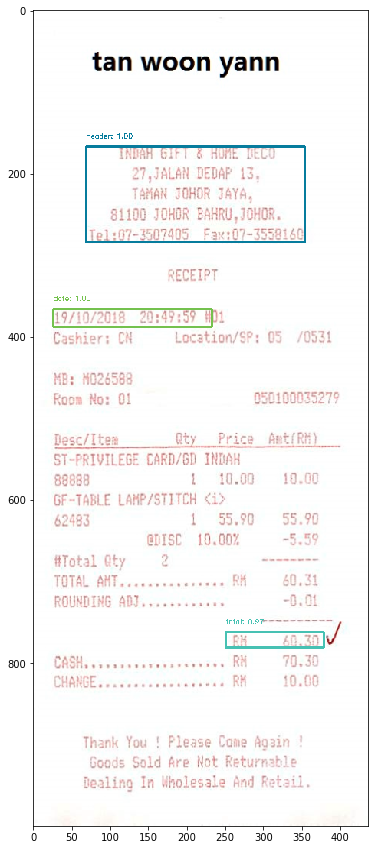

```python
path_to_model = '/content/invoice/rcnn/exported_model/frozen_inference_graph.pb'
path_to_labels = '/content/invoice/classes.pbtxt'
path_to_img = '/content/invoice/X00016469619.jpg'
predict(path_to_model, path_to_labels, path_to_img)
```

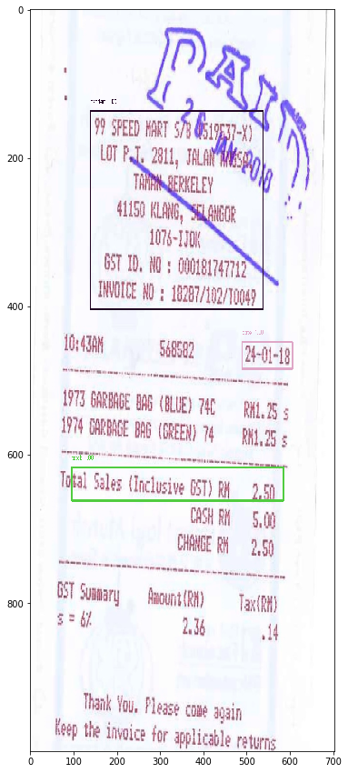

```python
path_to_model = '/content/invoice/rcnn/exported_model/frozen_inference_graph.pb'
path_to_labels = '/content/invoice/classes.pbtxt'
path_to_img = '/content/invoice/X51005361950.jpg'
predict(path_to_model, path_to_labels, path_to_img)
```